# Synaptosomal-associated protein 25

Fold-switch pair **1xtgB_3j97M** — **1xtgB** vs **3j97M**

Homo sapiens / Rattus norvegicus

## Figure 1: Phylogenetic tree with per-cluster fold-preference heatmap.

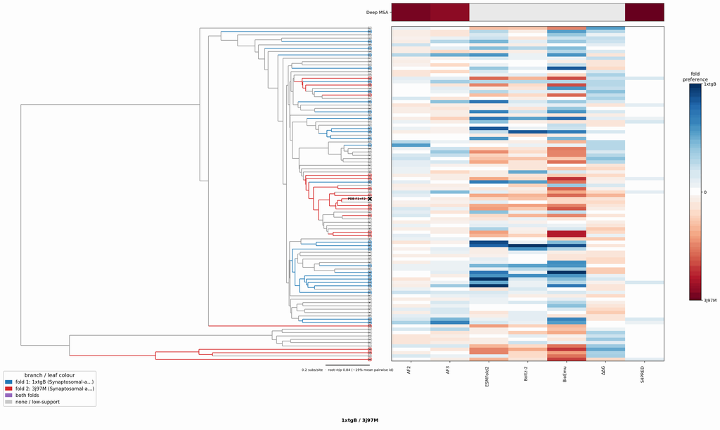

## Figure 2: Aligned overlay (both folds superposed)

The single fold-switching chain of each fold superposed by TM-align; waters hidden, any ligand shown as green sticks. Grey = structurally conserved core, colour = divergent (fold-switching) region. This pair switches fold coupled to oligomerisation; a single protomer is shown, not the full assembly.

1xtgB (Synaptosomal-associated protein 25) · dimer3j97M (Synaptosomal-associated protein 25) · 13-mer

TM-score: 0.074 · Trigger class: oligomerization

Aligned overlay

## Figure 3: The two folds, side by side

Each fold is coloured by per-residue Cα deviation between the two superposed structures: grey ≈ conserved core, full colour = structurally divergent (fold-switching) region.

1xtgB (Synaptosomal-associated protein 25)

3j97M (Synaptosomal-associated protein 25)

0 Å5≥10 Å

1xtgB (Synaptosomal-associated protein 25)

3j97M (Synaptosomal-associated protein 25)

## Figure 4: Best-cluster predicted contact maps over the two true folds.

Predicted contact maps (MSA-Transformer) for the clusters best matching each fold, over the true contacts of fold 1 (upper triangle) and fold 2 (lower). Divergent contacts between clusters are the contact-level signature of fold-switching.

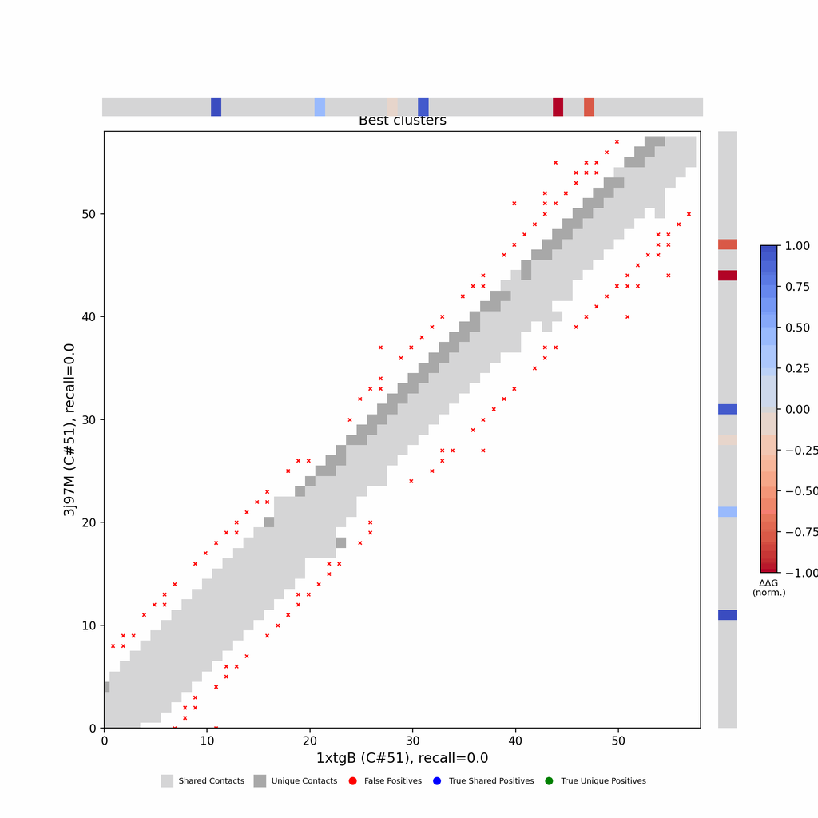

## Figure 5: Per-residue ΔΔG fold-preference contribution

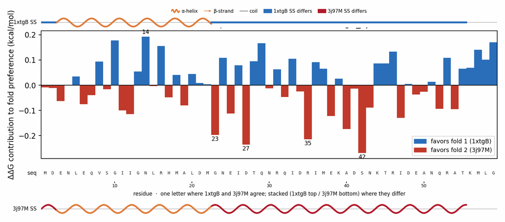

**More figures**

## Figure 6: Deep-MSA contact map panel / Best clusters contact map panel

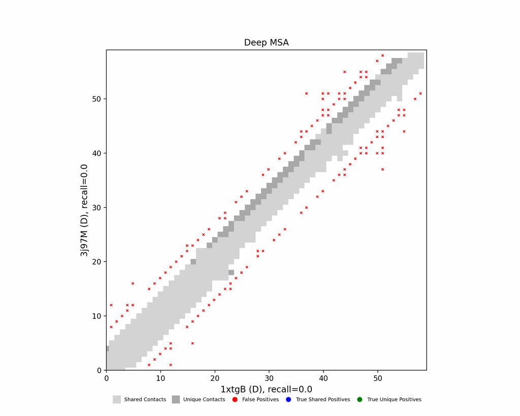

Deep-MSA contact map panel

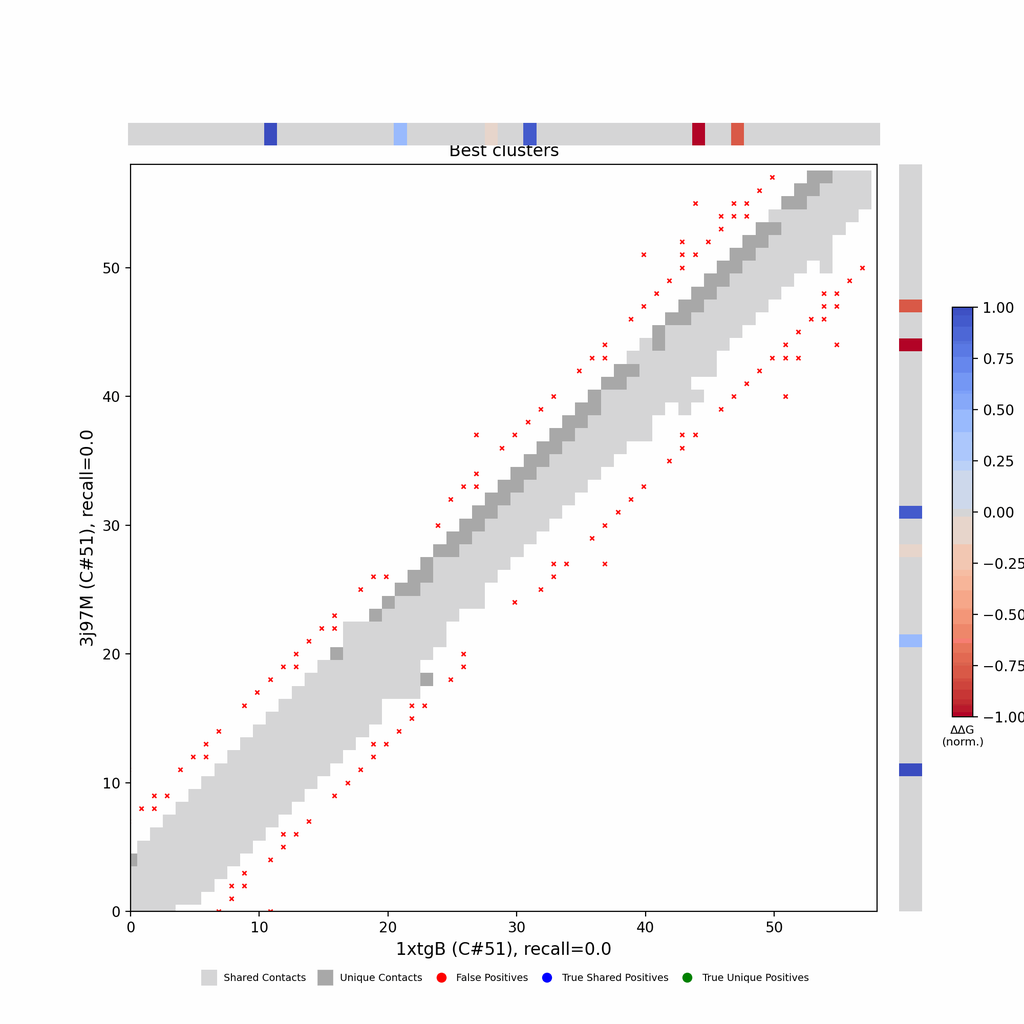

Best clusters contact map panel

## Figure 7: All clusters contact-map mosaic (small multiples).

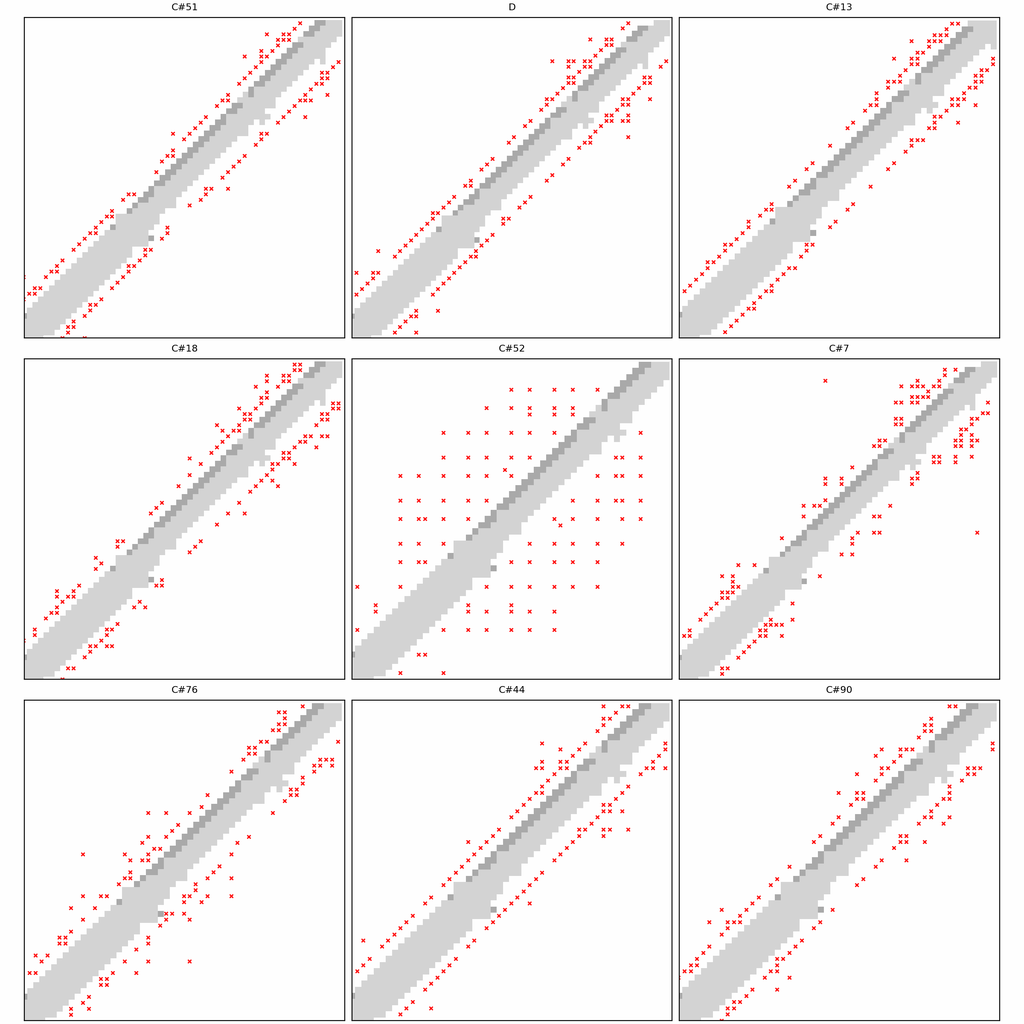

## Figure 8: Phylo null: tree with shuffled cluster fold labels.

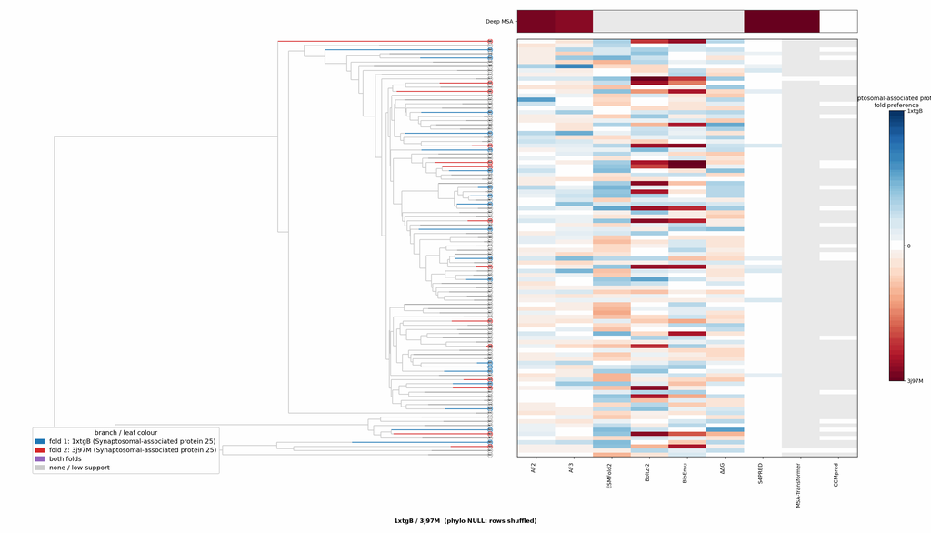

## Cluster metrics table

Per-cluster metrics underlying the figures above.

| cluster | n | neff | AF2_TM1 | AF2_TM2 | AF3_TM1 | AF3_TM2 | RE-MSAT-COM | RE-MSAT1 | RE-MSAT2 | ESM_SEQIDS | ESM_TM1 | ESM_TM2 | ΔΔG_Bias | ΔΔG_Bias_std | ΔΔG_frac_F1 | Boltz2_pref | S4PRED_pref | CCMpred_pref | BioEmu_pref |
| --- | --- | --- | --- | --- | --- | --- | --- | --- | --- | --- | --- | --- | --- | --- | --- | --- | --- | --- | --- |
| Deep | - | - | 0.35 | 0.48 | 0.35 | 0.47 | 0.0 | 0.0 | 0.53 | - | - | - | - | - | - | - | -0.42 | 0.0 | - |
| 000 | 1532.0 | 342.0 | 0.34 | 0.43 | 0.34 | 0.45 | - | - | 0.0 | 008; 008; 001; 001; 005; 007; 004; 009; 010; 004 | 0.35 ± 0.01 | 0.46 ± 0.02 | 4.81 | 1.58 | 1.0 | -0.06 | -0.42 | 0.0 | -0.01 |
| 001 | 614.0 | 353.0 | 0.33 | 0.46 | 0.34 | 0.45 | - | - | 0.0 | 010; 003; 002; 002; 003; 007; 007; 004; 009; 006 | 0.35 ± 0.01 | 0.45 ± 0.02 | 5.96 | 3.16 | 1.0 | -0.04 | -0.42 | 0.0 | -0.01 |
| 002 | 324.0 | 74.0 | 0.34 | 0.45 | 0.34 | 0.45 | - | - | 0.0 | 004; 005; 004; 005; 003; 003; 010; 007; 009; 007 | 0.35 ± 0.01 | 0.45 ± 0.03 | 3.84 | 2.31 | 1.0 | -0.05 | -0.42 | 0.0 | 0.04 |
| 003 | 313.0 | 133.0 | 0.34 | 0.46 | 0.33 | 0.45 | - | - | 0.0 | 004; 004; 006; 006; 001; 002; 009; 005; 002; 001 | 0.34 ± 0.01 | 0.46 ± 0.04 | 3.27 | 2.12 | 1.0 | -0.06 | -0.42 | 0.0 | -0.03 |
| 004 | 243.0 | 94.0 | 0.33 | 0.45 | 0.37 | 0.44 | - | - | 0.0 | 004; 004; 001; 002; 009; 007; 006; 005; 003; 002 | 0.34 ± 0.00 | 0.43 ± 0.06 | 5.64 | 2.37 | 1.0 | -0.03 | -0.42 | 0.0 | 0.03 |
| 005 | 218.0 | 80.0 | 0.34 | 0.46 | 0.33 | 0.46 | - | - | 0.0 | 005; 005; 001; 010; 001; 010; 006; 007; 008; 009 | 0.35 ± 0.01 | 0.45 ± 0.02 | 6.02 | 3.2 | 1.0 | -0.06 | -0.41 | 0.0 | 0.05 |
| 006 | 199.0 | 80.0 | 0.34 | 0.46 | 0.34 | 0.47 | - | - | 0.0 | 003; 003; 001; 002; 009; 008; 007; 005; 002; 001 | 0.34 ± 0.00 | 0.43 ± 0.04 | 3.02 | 1.47 | 1.0 | -0.05 | -0.41 | 0.0 | 0.01 |
| 007 | 160.0 | 12.0 | 0.33 | 0.45 | 0.34 | 0.45 | 0.0 | 0.0 | 0.0 | 009; 009; 001; 004; 002; 002; 001; 004; 008; 007 | 0.35 ± 0.01 | 0.44 ± 0.03 | 2.47 | 2.48 | 0.8 | -0.1 | -0.42 | 0.0 | -0.04 |
| 008 | 160.0 | 50.0 | 0.33 | 0.42 | 0.33 | 0.38 | - | - | 0.0 | 004; 004; 008; 008; 001; 007; 005; 001; 007; 005 | 0.36 ± 0.02 | 0.48 ± 0.07 | 2.08 | 0.82 | 1.0 | -0.07 | -0.38 | 0.0 | -0.06 |
| 009 | 159.0 | 93.0 | 0.33 | 0.46 | 0.33 | 0.45 | - | - | 0.0 | 008; 005; 005; 008; 001; 002; 009; 006; 004; 003 | 0.34 ± 0.00 | 0.44 ± 0.02 | 5.47 | 2.91 | 1.0 | 0.11 | -0.42 | 0.0 | 0.07 |
| 010 | 151.0 | 86.0 | 0.33 | 0.44 | 0.33 | 0.44 | - | - | 0.0 | 001; 009; 009; 008; 005; 002; 002; 010; 001; 008 | 0.34 ± 0.00 | 0.44 ± 0.02 | 4.41 | 3.04 | 1.0 | -0.09 | -0.42 | 0.0 | -0.11 |
| 011 | 146.0 | 37.0 | 0.34 | 0.45 | 0.34 | 0.46 | - | - | 0.0 | 003; 003; 001; 002; 009; 008; 006; 005; 004; 002 | 0.34 ± 0.00 | 0.45 ± 0.02 | 8.57 | 3.18 | 1.0 | -0.11 | -0.42 | 0.0 | -0.07 |
| 012 | 134.0 | 122.0 | 0.33 | 0.44 | 0.34 | 0.44 | - | - | 0.0 | 001; 010; 009; 006; 004; 003; 002; 002; 001; 009 | 0.34 ± 0.00 | 0.41 ± 0.02 | 4.16 | 1.78 | 1.0 | 0.05 | -0.42 | 0.0 | 0.05 |
| 013 | 124.0 | 73.0 | 0.35 | 0.45 | 0.35 | 0.44 | 0.0 | 0.0 | 0.25 | 001; 008; 008; 001; 006; 007; 009; 002; 002; 003 | 0.34 ± 0.00 | 0.46 ± 0.04 | 6.93 | 2.19 | 1.0 | -0.09 | -0.42 | 0.0 | -0.08 |
| 014 | 116.0 | 29.0 | 0.33 | 0.45 | 0.33 | 0.45 | - | - | 0.0 | 002; 002; 005; 005; 001; 010; 001; 010; 008; 009 | 0.35 ± 0.01 | 0.46 ± 0.02 | 2.26 | 1.09 | 1.0 | -0.06 | -0.42 | 0.0 | -0.11 |
| 015 | 115.0 | 35.0 | 0.36 | 0.44 | 0.34 | 0.44 | - | - | 0.0 | 005; 005; 010; 004; 004; 010; 002; 007; 006; 002 | 0.35 ± 0.01 | 0.47 ± 0.02 | 6.26 | 3.03 | 1.0 | -0.06 | -0.42 | 0.0 | -0.06 |
| 016 | 115.0 | 47.0 | 0.34 | 0.46 | 0.38 | 0.44 | - | - | 0.0 | 010; 004; 004; 007; 010; 002; 009; 007; 003; 002 | 0.34 ± 0.00 | 0.43 ± 0.03 | 3.02 | 1.1 | 1.0 | -0.04 | -0.42 | 0.0 | 0.07 |
| 017 | 114.0 | 29.0 | 0.34 | 0.46 | 0.33 | 0.44 | - | - | 0.0 | 004; 007; 004; 005; 007; 005; 001; 002; 009; 008 | 0.35 ± 0.01 | 0.45 ± 0.03 | 2.65 | 1.16 | 1.0 | -0.04 | -0.42 | 0.0 | 0.01 |
| 018 | 111.0 | 23.0 | 0.34 | 0.45 | 0.33 | 0.44 | 0.0 | 0.0 | 0.0 | 004; 006; 006; 004; 001; 002; 007; 005; 002; 001 | 0.34 ± 0.00 | 0.42 ± 0.05 | 3.91 | 2.08 | 1.0 | -0.1 | -0.4 | 0.0 | -0.05 |
| 019 | 111.0 | 22.0 | 0.34 | 0.44 | 0.33 | 0.44 | - | - | 0.0 | 006; 006; 003; 003; 001; 002; 009; 008; 004; 002 | 0.35 ± 0.02 | 0.44 ± 0.02 | 6.74 | 2.28 | 1.0 | -0.09 | -0.42 | 0.0 | -0.08 |
| 020 | 109.0 | 10.0 | 0.34 | 0.46 | 0.37 | 0.43 | - | - | 0.0 | - | - | - | 5.51 | 2.97 | 1.0 | -0.09 | -0.42 | - | -0.07 |
| 021 | 109.0 | 36.0 | 0.36 | 0.45 | 0.34 | 0.47 | - | - | 0.0 | - | - | - | 6.52 | 2.86 | 1.0 | -0.06 | -0.42 | - | -0.02 |
| 022 | 103.0 | 15.0 | 0.34 | 0.47 | 0.34 | 0.47 | - | - | 0.0 | - | - | - | 2.68 | 1.81 | 0.9 | -0.13 | -0.42 | - | -0.07 |
| 023 | 102.0 | 5.0 | 0.34 | 0.45 | 0.33 | 0.45 | - | - | 0.0 | - | - | - | 3.8 | 2.49 | 1.0 | -0.04 | -0.42 | - | -0.03 |
| 024 | 101.0 | 66.0 | 0.33 | 0.46 | 0.34 | 0.45 | - | - | 0.0 | - | - | - | 5.12 | 2.54 | 1.0 | -0.01 | -0.42 | - | 0.06 |
| 025 | 99.0 | 9.0 | 0.34 | 0.46 | 0.34 | 0.44 | - | - | 0.0 | - | - | - | 2.6 | 0.62 | 1.0 | -0.04 | -0.42 | - | 0.03 |
| 026 | 99.0 | 10.0 | 0.34 | 0.46 | 0.34 | 0.45 | - | - | 0.0 | - | - | - | 1.99 | 1.24 | 0.9 | -0.06 | -0.42 | - | -0.04 |
| 027 | 98.0 | 37.0 | 0.33 | 0.45 | 0.34 | 0.45 | - | - | 0.0 | - | - | - | 5.97 | 2.74 | 1.0 | -0.09 | -0.42 | - | -0.08 |
| 028 | 94.0 | 40.0 | 0.33 | 0.44 | 0.35 | 0.43 | - | - | 0.0 | - | - | - | 6.34 | 3.48 | 1.0 | -0.07 | -0.42 | - | -0.08 |

[output cut: 71 more lines]